# CAPÍTULO IV. TRABAJO EN EL HOGAR Y DE CUIDADOS (TRABAJO NO REMUNERADO) Y LA DEPENDENCIA ECONÓMICA

Edgardo Flores Gutiérrez

2025-09-28

## Introducción

El siguiente análisis se sustenta en la ENIGH tabla “poblacion” del 2024 publicada por el INEGI, centrándose en la tabla de datos “poblacion”, que nos permite conocer las características sociodemográficas y ocupacionales de los integrantes del hogar, ademas de la variable tam_loc que indica el tamaño de localidad, que se encuentra en la tabla viviendas.

La encuesta contiene un diseño muestral estatrificado, con representatividad nacional y subnacional, por lo que, la encuesta cuenta con tres variables para la realización del diseño muestral y realizar inferencia estadística:

1. factor: peso de expansión
2. est_dis: estrato
3. upm: unidad primaria de muestreo.

El análisis tiene como objetivo conocer el trabajo no remunerado en el hogar con un enfoque de género, identificando las horas dedicadas a actividades que no son remuneradas y la dependencia económica de las mujeres dentro de los hogares.

Estructura del análisis:

- Definición del diseño muestral
- Análisis estadístico por segmento:
  - Medidas de tendencia central
  - Comparación de medias y medianas entre grupos
- Visualización de resultados (Data visualization)
- Modelo de regresión final con ajuste por diseño muestral (opcional)

## Diseño muestral

El diseño muestral con el que fue recolectada la ENIGH 2024 valida los resultados del análisis estadístico,

De acuerdo con el documento metodológico de la ENIGH 2024 Nueva Serie Descripción de la base de datos (INEGI, Capítulo 4) est_dis corresponde a un código de estrato estadístico definido por características como: • Nivel de urbanización (urbano/rural) • Tamaño de localidad • Categoría de la entidad federativa (grande, mediana, pequeña) • Dominio de estudio (entidad, ciudad, región)

UPM identifica cada Unidad Primaria de Muestreo, que en zonas urbanas equivale generalmente a una manzana o conjunto de manzanas, y en zonas rurales, a localidades. Las UPM se seleccionan con probabilidad proporcional al tamaño poblacional, y constituyen la base para la selección de viviendas.

Factor: el factor de expansión constituye el peso que se le da a cada unidad muestral para generalizar los resultados de la muestra a la población.

El **diseño muestral** es el plan o estrategia que se utiliza para seleccionar una muestra a partir de una población más grande. En esencia, es el conjunto de procedimientos que nos permite elegir un subgrupo representativo (la muestra) de un grupo total (la población) con el fin de estudiarlo y poder generalizar los resultados a toda la población.

El objetivo principal es obtener información precisa y confiable sobre la población sin tener que estudiar a cada uno de sus individuos, lo que a menudo sería demasiado costoso, lento o simplemente imposible.

## Análisis estadístico

Para realizar un análisis estádistico correcto, es preciso conocer la cantidad de personas que representa el diseño muestral, así como las medidas de tendencia central.

Población total que realiza trabajo no remunerado (por sexo)

|  | Total | Error_Estandar |
| --- | --- | --- |
| sexoHombre | 69,202,440 | 493,317 |
| sexoMujer | 70,799,583 | 508,872 |

```
## El número total de personas (población expandida) que realizan trabajo no remunerado es: 140,002,023
```

### Edad

- Edad promedio y mediana de la población que realiza trabajo no remunerado (por sexo)

```
##     sexo media  se_media mediana se_mediana
## 1 Hombre    43 0.1125584      41  0.2550750
## 2  Mujer    44 0.1057349      42  0.2550753
```

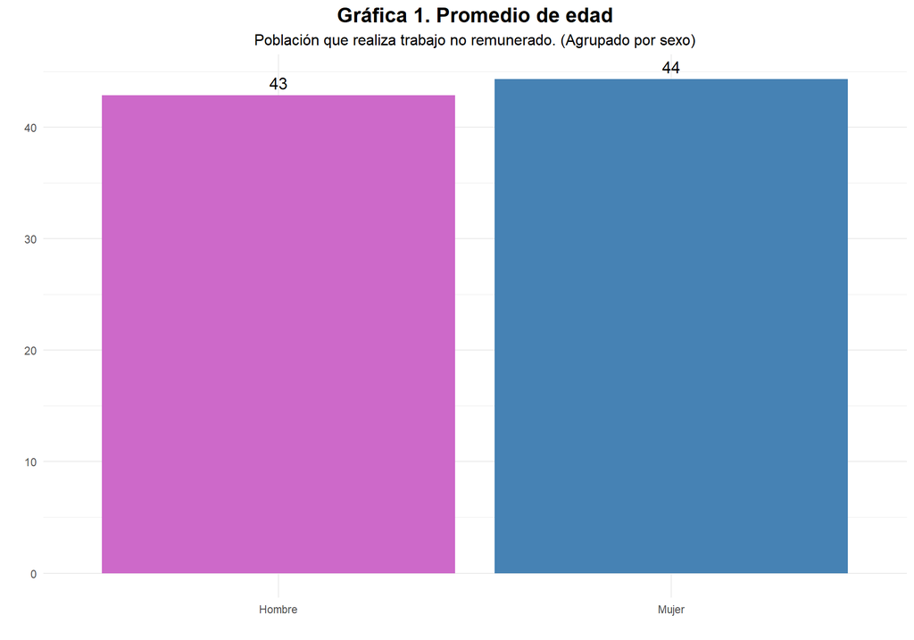

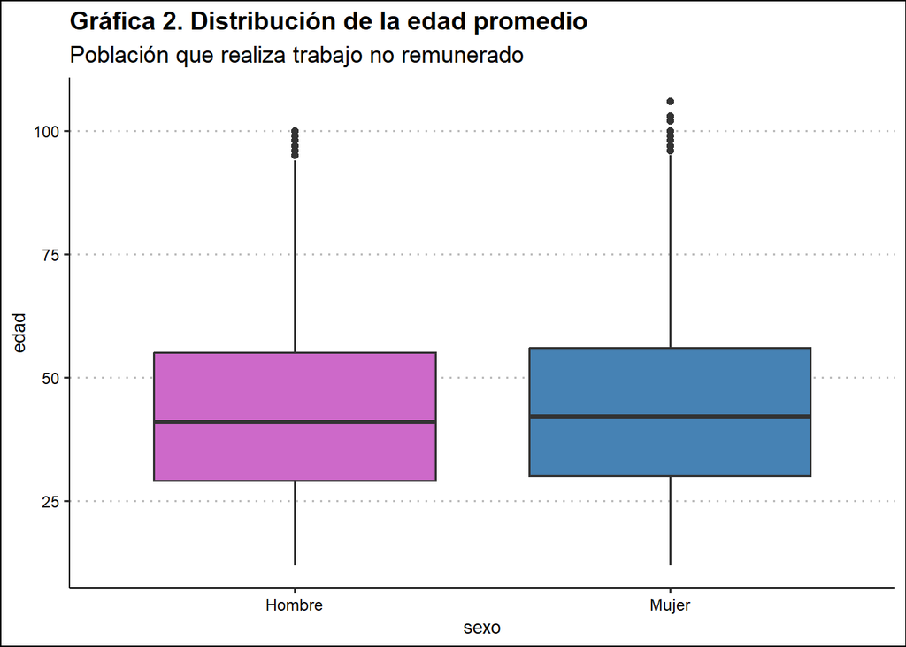

### Horas

- Horas semanales promedio y mediana de trabajo no remunerado (por sexo)

```
##     sexo    media   se_media mediana se_mediana media_hm mediana_hm
## 1 Hombre 14.10936 0.09624533      10  0.2550750 14:06:34   10:00:00
## 2  Mujer 26.24298 0.16949176      21  0.2550753 26:14:35   21:00:00
```

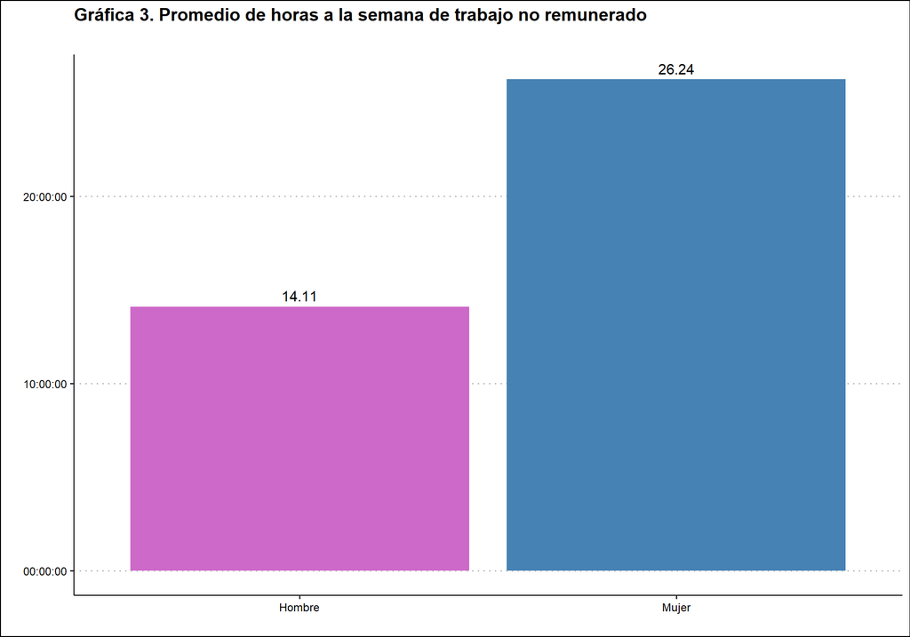

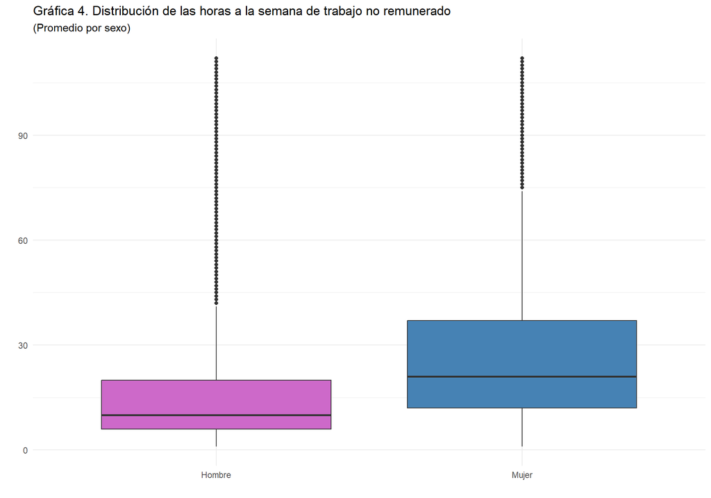

Dada la fuerte asimetria y la gran cantidad de valores atípicos (outliers) en las horas de trabajo no remunerado (Gráfica 4), la **mediana** es una medida de tendencia central mucho más adecuada y robusta que la **media**.

### Horas de trabajo no remunerado (por etnia y sexo)

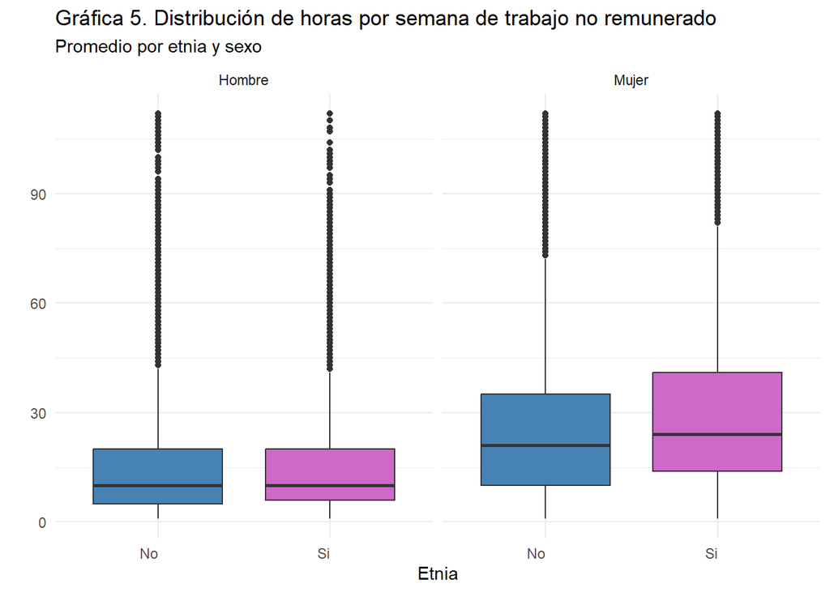

### Horas de trabajo no remunerado (por afrodescendencia y sexo)

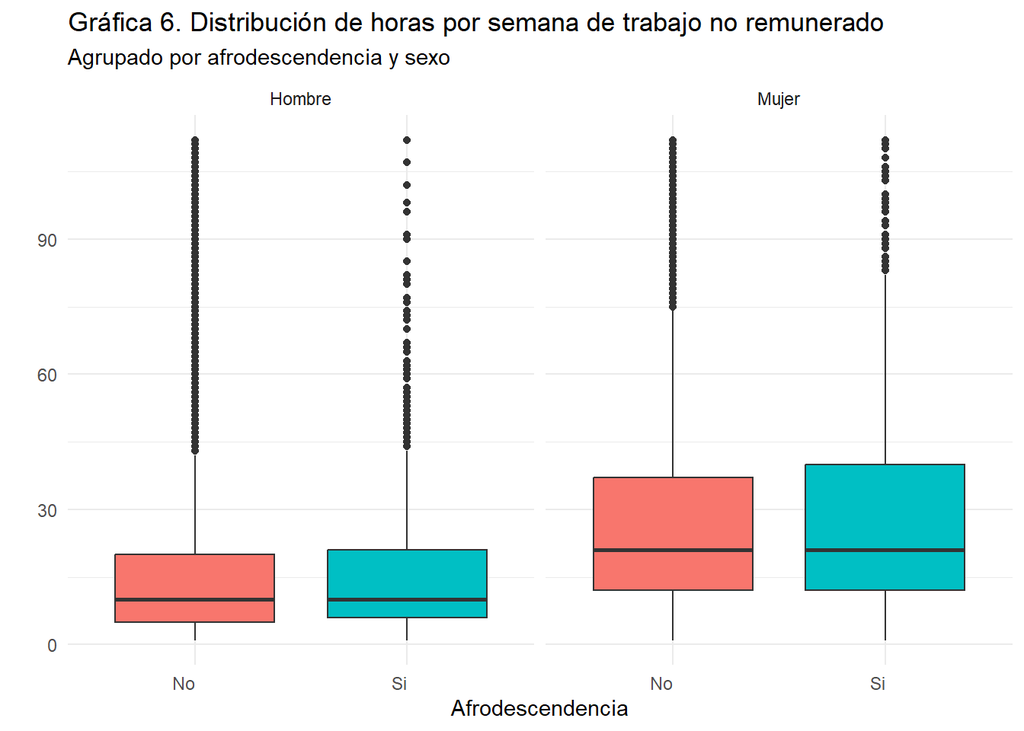

### Horas semanales de trabajo no remunerado (zona y sexo)

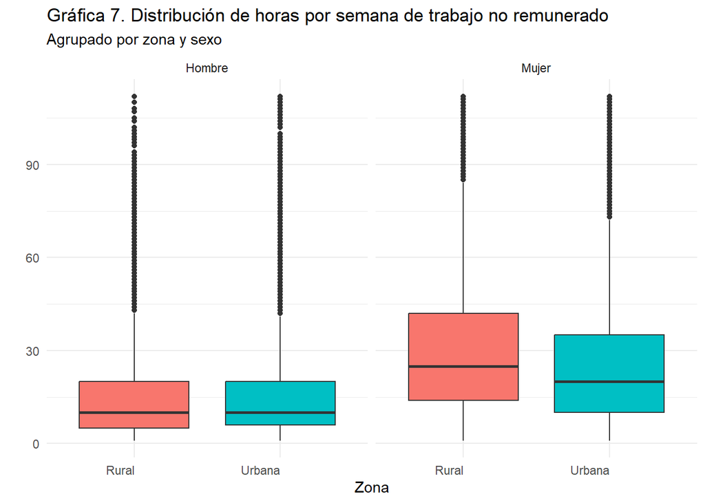

### Horas de trabajo no remunerado (por región y sexo)

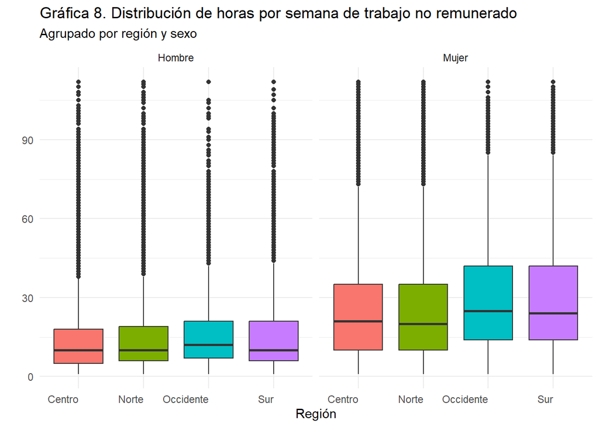

### Normalización de la variable horas de trabajo no remunerado

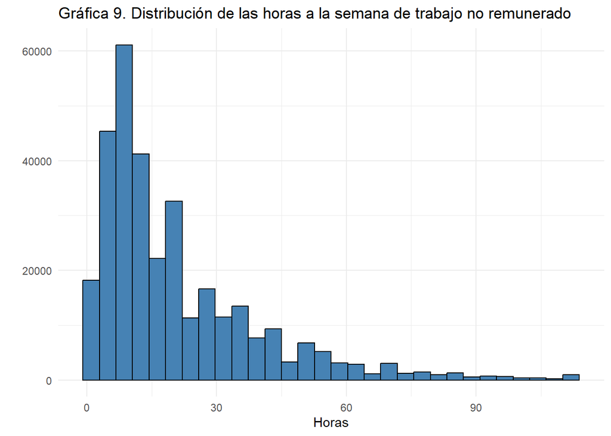

Como se observa en la gráfica 9, la distribución está claramente “cargada” hacia la izquierda, con una cola larga hacia la derecha. Esto significa que la mayoría de las personas reportan una cantidad relativamente baja de horas de trabajo no remunerado, pero un número menor de personas reporta una cantidad extremadamente alta. **La media no es representativa:** En una distribución como esta, la media aritmética será afectada por los valores altos, provocando un valor central inflado . La **mediana** será una medida mucho más robusta de lo que hace la “persona típica”.

#### Transformación Logarítimica

Con la intención de normalizar los datos, se realiza una transformación logarítmica. El objetivo es crear una nueva columna que contenga el logaritmo de las horas de trabajo no remunerado.

#### Justificación de la Transformación Logarítmica

La decisión de transformar una variable $Y$ a $log(Y)$ no es una medida arbitraria para alterar la escala de los datos, sino un procedimiento estándar en econometría y estadística que se justifica por una o más de las siguientes razones teóricas y prácticas:

- **Mecanismo de Acción:** La función logarítmica es cóncava, lo que significa que “comprime” la escala de los valores altos en mayor medida que la de los valores bajos. Esto reduce el impacto de los valores extremos en la cola derecha de la distribución, resultando en una distribución transformada mucho más simétrica y, a menudo, aproximadamente normal.
- **Beneficio Estadístico:** Al normalizar la distribución de la variable (o, más precisamente, la de los residuos del modelo), se obtienen estimadores más eficientes y se valida el uso de pruebas de significancia (valores p) y la construcción de intervalos de confianza, los cuales dependen del supuesto de normalidad.

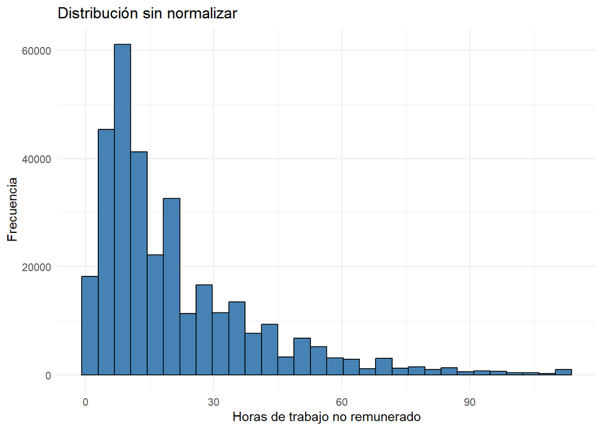

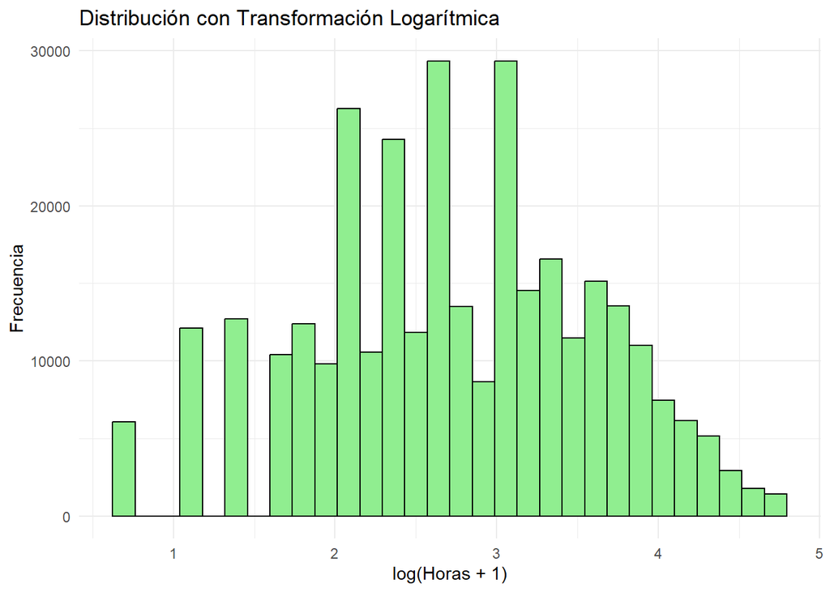

```
## [1] "Media Aritmética Original (sesgada): 20.88"
```

```
## [1] "Mediana Original (robusta): 14"
```

```
## [1] "Media Geométrica (robusta e interpretable): 14.37"
```

## Comparación de medias y medianas entre grupos

|  | sexo | entidad | etnia | afrod | horas_tnr | se |
| --- | --- | --- | --- | --- | --- | --- |
| Hombre.Aguascalientes.No.No | Hombre | Aguascalientes | No | No | 13.46928 | 0.5015096 |
| Mujer.Aguascalientes.No.No | Mujer | Aguascalientes | No | No | 23.94415 | 0.6316116 |
| Hombre.Baja California.No.No | Hombre | Baja California | No | No | 11.67846 | 0.4058338 |
| Mujer.Baja California.No.No | Mujer | Baja California | No | No | 17.98519 | 0.5276950 |
| Hombre.Baja California Sur.No.No | Hombre | Baja California Sur | No | No | 12.04021 | 0.4232152 |
| Mujer.Baja California Sur.No.No | Mujer | Baja California Sur | No | No | 20.08821 | 0.6683770 |

|  | sexo | entidad | etnia | afrod | horas_tnr | se.horas_tnr |
| --- | --- | --- | --- | --- | --- | --- |
| Hombre.Aguascalientes.No.No | Hombre | Aguascalientes | No | No | 10 | 0.5083365 |
| Mujer.Aguascalientes.No.No | Mujer | Aguascalientes | No | No | 17 | 1.2708977 |
| Hombre.Baja California.No.No | Hombre | Baja California | No | No | 8 | 0.5087502 |
| Mujer.Baja California.No.No | Mujer | Baja California | No | No | 14 | 0.2543768 |
| Hombre.Baja California Sur.No.No | Hombre | Baja California Sur | No | No | 8 | 0.5083535 |
| Mujer.Baja California Sur.No.No | Mujer | Baja California Sur | No | No | 14 | 0.5083017 |

## Visualización de resultados

Gráficos:

[figure not shown]

### Gráficas con media normalizada

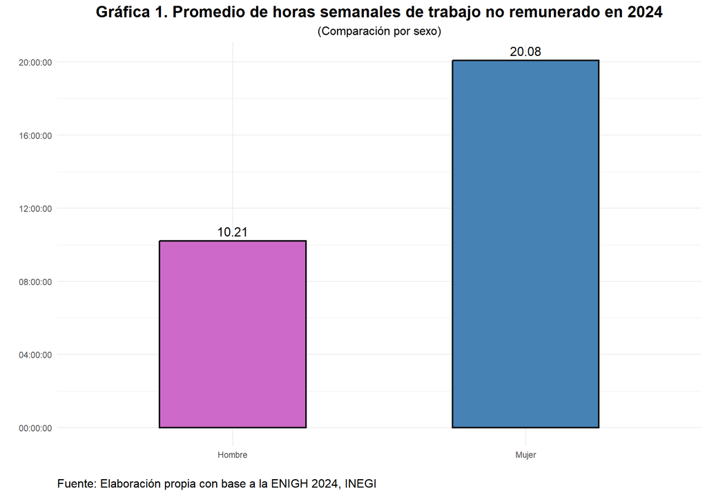

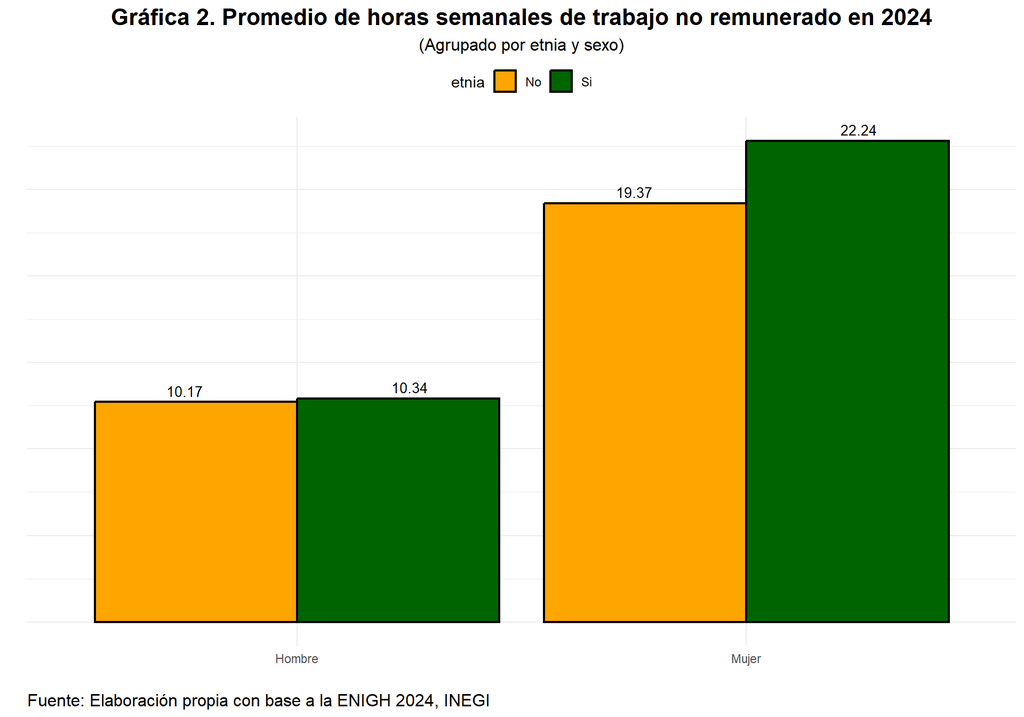

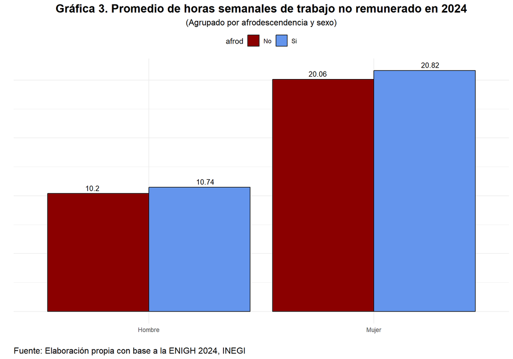

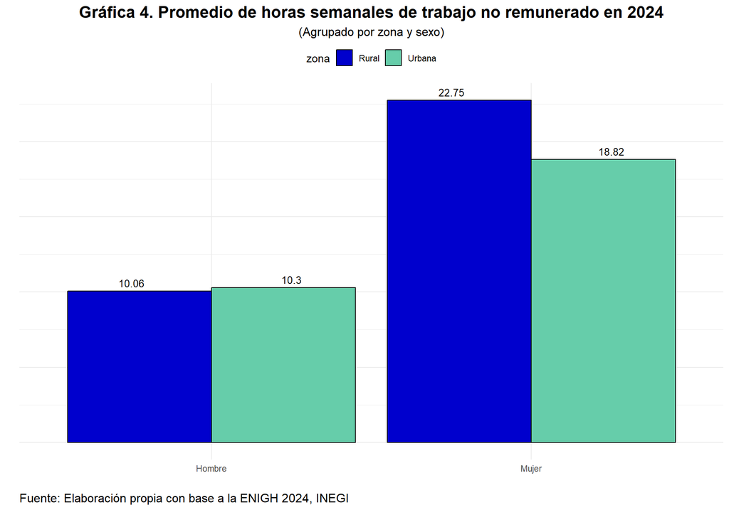

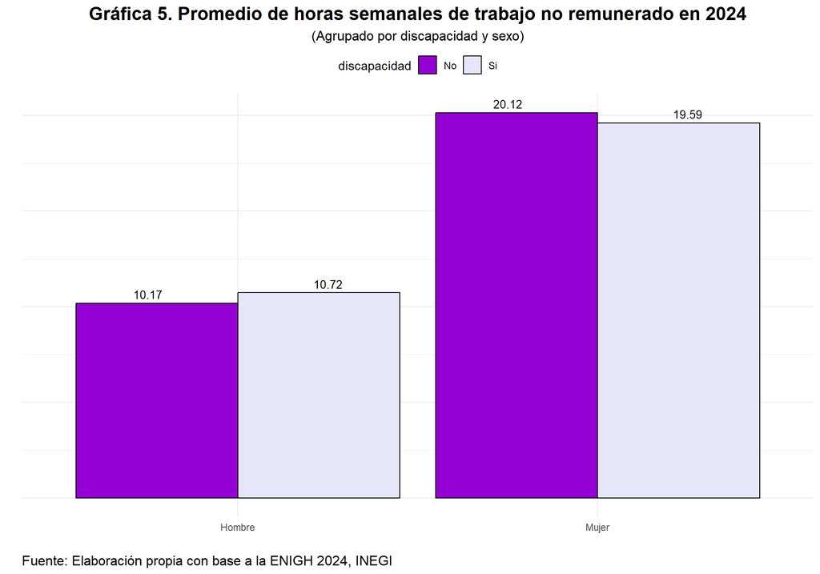

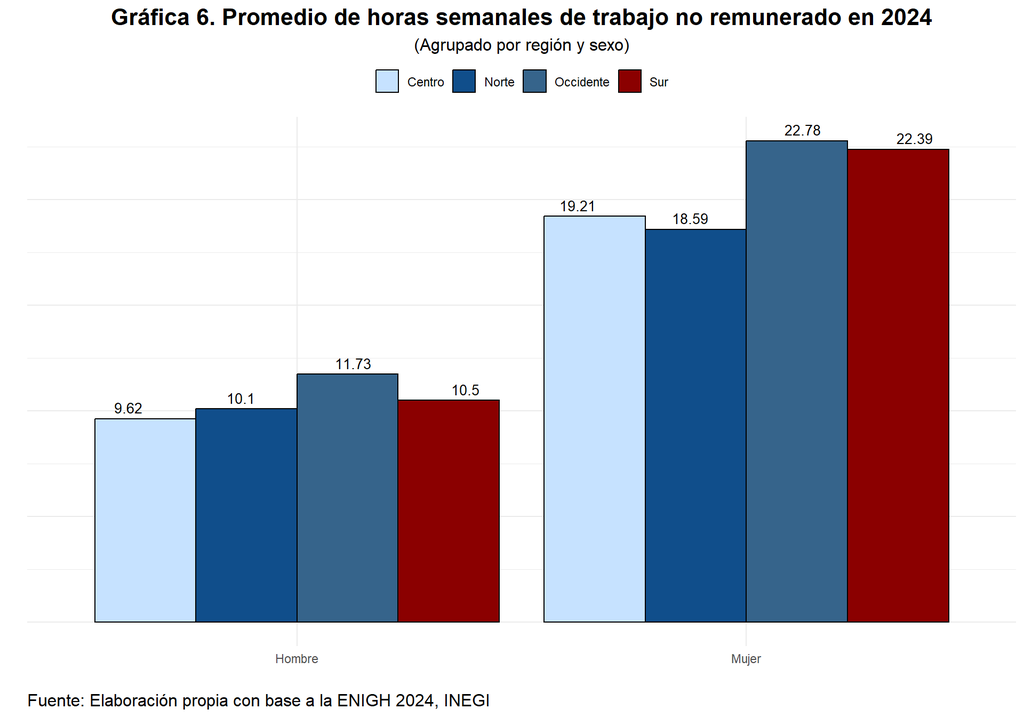

#### Gráfico Combinado

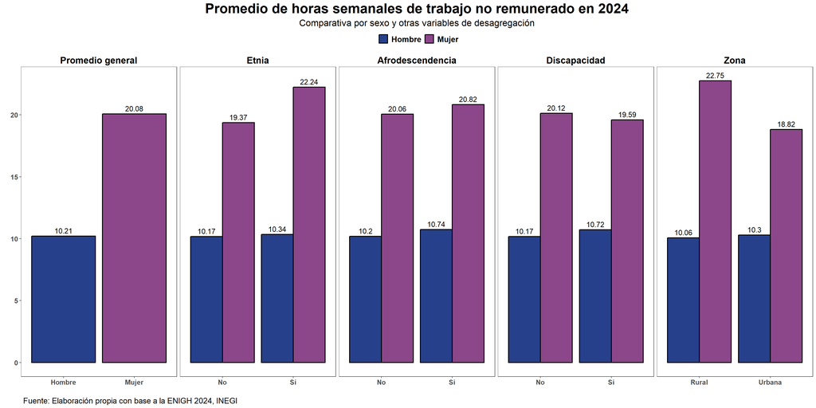